# Homework 7: Tuesday Exercises

Ishaan Sathaye

## Question 1

Use the context and data of textbook exercise #8.9, but ignore the textbook’s instructions. Instead, conduct a discriminant analysis, applying graphical and statistical techniques that we have learned in class.

```r
library(MVN)
library(GGally)
library(MASS)
library(dplyr)
library(caret)
```

**Data:**

```r
setwd(dirname(rstudioapi::getActiveDocumentContext()$path))
musc <- read.table(file="../../data/T5_7_MUSCDYS.DAT",
                   col.names = c("group", "age", "month", "creatine", "hemo", "lactate",
                                 "pyruvate"))
musc$group <- as.factor(musc$group)
head(musc, n=5)
```

```
##   group age month creatine  hemo lactate pyruvate
## 1     1  22     6       52  83.5    10.9      176
## 2     1  32     8       20  77.0    11.0      200
## 3     1  36     7       28  86.5    13.2      171
## 4     1  22    11       30 104.0    22.6      230
## 5     1  23     1       40  83.0    15.2      205
```

```r
tail(musc, n=5)
```

```
##    group age month creatine hemo lactate pyruvate
## 69     2  38     1      113   97    18.8      216
## 70     2  30     8       57  105    12.9      155
## 71     2  42     8       78  118    15.5      212
## 72     2  43    11       73  104    20.6      201
## 73     2  29     3       69  111    16.0      175
```

where y1 = age, y2 = month in which measurements were taken, y3 = creatine kinase, y4 = hemopexim, y5 = lactate dehydrogenase, y6 = pyruvate kinase.

The groups are 1 being the noncarriers and 2 being the carriers.

**Graphical Analysis:**

```r
musc |>
  group_by(group) |>
  summarise(meanAge = mean(age),
            meanMonth = mean(month),
            meanCreatine = mean(creatine),
            meanHemo = mean(hemo),
            meanLactate = mean(lactate),
            meanPyruvate = mean(pyruvate))
```

```
## # A tibble: 2 × 7
##   group meanAge meanMonth meanCreatine meanHemo meanLactate meanPyruvate
##   <fct>   <dbl>     <dbl>        <dbl>    <dbl>       <dbl>        <dbl>
## 1 1        27.3      6.51         43.1     79.6        12.5         165.
## 2 2        34.9      6.12        156.      94.0        26.3         248.
```

Taking a look at the sample means, it seems that the means for creatine, hemo, lactate, and pyruvate are different for the carriers and non-carriers, which could hint at their usefulness in separation.

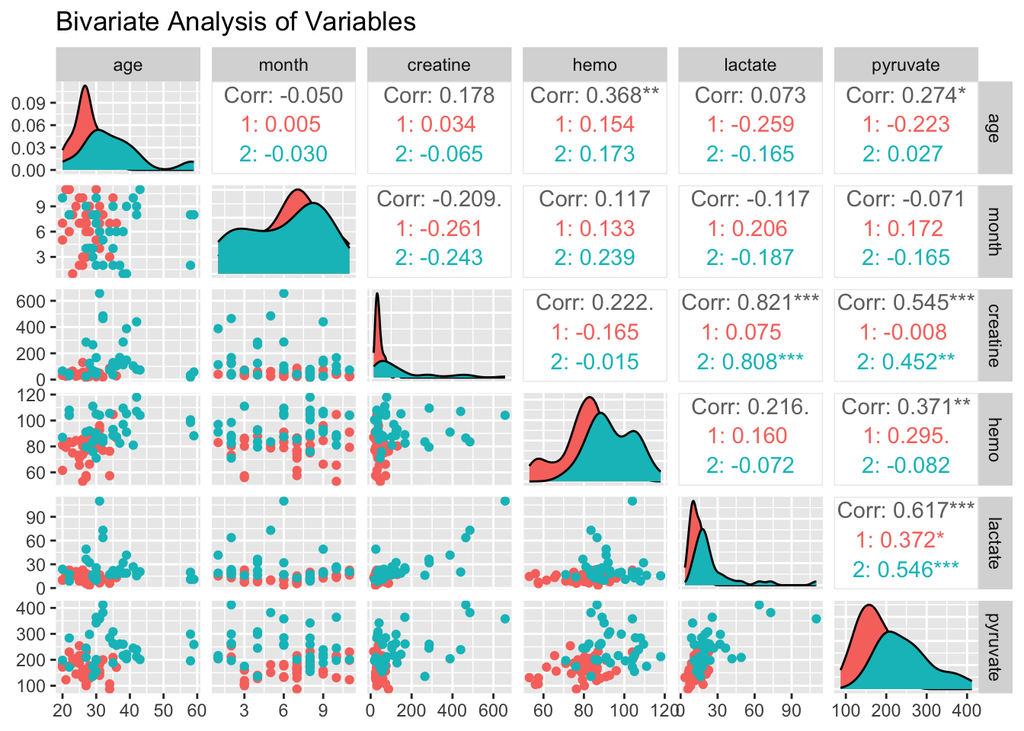

```r
ggpairs(musc[,-1], mapping = aes(colour=musc$group), title = "Bivariate Analysis of Variables")
```

From this scatterplot matrix, the variables which seem to be helpful in a discriminant analysis could be hemopexim, pyruvate, and lactate as these variables have some degree of data separation in terms of the groups of carriers and non-carriers.

**Linear Discriminant Analysis:**

```r
muscLDA <- lda(group ~ ., data=musc)
muscLDA
```

```
## Call:
## lda(group ~ ., data = musc)
##
## Prior probabilities of groups:
##         1         2
## 0.5342466 0.4657534
##
## Group means:
##        age    month  creatine     hemo  lactate pyruvate
## 1 27.25641 6.512821  43.05128 79.61538 12.53590 164.9744
## 2 34.91176 6.117647 155.61765 94.00882 26.27059 247.5000
##
## Coefficients of linear discriminants:
##                   LD1
## age       0.065651640
## month    -0.023395534
## creatine  0.002227237
## hemo      0.040177323
## lactate   0.003343986
## pyruvate  0.009952229
```

```r
musczvalues <- predict(muscLDA)
muscLDA <- cbind(musc, musczvalues$x)
head(muscLDA)
```

```
##   group age month creatine  hemo lactate pyruvate        LD1
## 1     1  22     6       52  83.5    10.9      176 -1.0812497
## 2     1  32     8       20  77.0    11.0      200 -0.5647607
## 3     1  36     7       28  86.5    13.2      171 -0.1605140
## 4     1  22    11       30 104.0    22.6      230  0.1529535
## 5     1  23     1       40  83.0    15.2      205 -0.6424422
## 6     1  30     5       24  78.8     9.6      151 -1.0369900
```

```r
means <- muscLDA |>
  group_by(group) |>
  summarise(meanz=mean(LD1))
means
```

```
## # A tibble: 2 × 2
##   group meanz
##   <fct> <dbl>
## 1 1     -1.03
## 2 2      1.18
```

From this analysis, we can get the coefficients of the only 1 discriminant function. The mean of the z scores of the discriminant function show how far they can be pushed as far as possible from each other. However, we can not make any conclusions about these variables, since the data was not standardized.

**Standardized Coefficients:**

```r
muscStd <- scale(musc[,-1])
muscStd <- data.frame(group = musc$group, muscStd)
head(muscStd)
```

```
##   group        age      month   creatine        hemo    lactate    pyruvate
## 1     1 -1.1094186 -0.1160245 -0.3530267 -0.20640681 -0.5026201 -0.40151375
## 2     1  0.1481522  0.5897910 -0.6128472 -0.68230590 -0.4963631 -0.04996348
## 3     1  0.6511805  0.2368833 -0.5478921  0.01323892 -0.3587082 -0.47475339
## 4     1 -1.1094186  1.6485142 -0.5316533  1.29450569  0.2294533  0.38947435
## 5     1 -0.9836616 -1.8805631 -0.4504594 -0.24301443 -0.2335675  0.02327616
## 6     1 -0.1033620 -0.4689322 -0.5803696 -0.55051846 -0.5839616 -0.76771194
```

```r
muscStdLDA <- lda(group ~ ., data=muscStd)
muscStdLDA
```

```
## Call:
## lda(group ~ ., data = muscStd)
##
## Prior probabilities of groups:
##         1         2
## 0.5342466 0.4657534
##
## Group means:
##          age       month   creatine       hemo    lactate   pyruvate
## 1 -0.4483878  0.06495386 -0.4256848 -0.4908199 -0.4002614 -0.5630165
## 2  0.5143272 -0.07450590  0.4882855  0.5629993  0.4591234  0.6458131
##
## Coefficients of linear discriminants:
##                  LD1
## age       0.52205124
## month    -0.06629363
## creatine  0.27431087
## hemo      0.54875625
## lactate   0.05344360
## pyruvate  0.67942914
```

From this output, the most important variables that contribute to separation are pyruvate, hemopexim, and age, with creatine also being somewhat important and these are in the order of their magnitude of their coefficients. Furthermore, we can test whether certain variables contribute significantly towards the separation of group means, after controlling for the separation attributable to all other variables.

```r
mvn(data = musc, subset = "group", mvnTest = "mardia")
```

```
## $multivariateNormality
## $multivariateNormality$`1`
##              Test         Statistic           p value Result
## 1 Mardia Skewness  67.9513942017654 0.131424033446004    YES
## 2 Mardia Kurtosis 0.229808802056305  0.81824034471505    YES
## 3             MVN              <NA>              <NA>    YES
##
## $multivariateNormality$`2`
##              Test         Statistic             p value Result
## 1 Mardia Skewness  89.4991631730404 0.00296633968577909     NO
## 2 Mardia Kurtosis 0.900099446163835   0.368067330747139    YES
## 3             MVN              <NA>                <NA>     NO
##
##
## $univariateNormality
## $univariateNormality$`1`
##               Test  Variable Statistic   p value Normality
## 1 Anderson-Darling    age       0.5331    0.1621    YES
## 2 Anderson-Darling   month      0.6805    0.0697    YES
## 3 Anderson-Darling creatine     1.6675    0.0002    NO
## 4 Anderson-Darling   hemo       0.6825    0.0690    YES
## 5 Anderson-Darling  lactate     0.3102    0.5400    YES
## 6 Anderson-Darling pyruvate     0.1407    0.9706    YES
##
## $univariateNormality$`2`
##               Test  Variable Statistic   p value Normality
## 1 Anderson-Darling    age       1.2108  0.0032      NO
## 2 Anderson-Darling   month      1.0401  0.0085      NO
## 3 Anderson-Darling creatine     3.0215  <0.001      NO
## 4 Anderson-Darling   hemo       0.4884  0.2085      YES
## 5 Anderson-Darling  lactate     3.5551  <0.001      NO
## 6 Anderson-Darling pyruvate     0.6281  0.0934      YES
##
##
## $Descriptives
## $Descriptives$`1`
##           n       Mean   Std.Dev Median  Min   Max  25th   75th       Skew
## age      39  27.256410  3.951801   27.0 20.0  36.0  25.0  30.00  0.2380091
## month    39   6.512821  2.703524    7.0  1.0  11.0   4.5   8.00 -0.1927700
## creatine 39  43.051282 22.205913   37.0 15.0 130.0  29.0  50.00  1.7666351
```

[output cut: 11 more lines]

```
## $Descriptives$`2`
##           n       Mean    Std.Dev Median   Min Max    25th   75th       Skew
## age      34  34.911765   9.365856  33.00  20.0  59  29.250  38.75  1.0740350
## month    34   6.117647   3.002673   6.50   1.0  11   4.000   8.00 -0.2662439
## creatine 34 155.617647 159.853724  91.00  19.0 657  47.750 167.75  1.5135119
## hemo     34  94.008824  11.220014  91.50  71.0 118  86.625 104.00  0.1164445
## lactate  34  26.270588  20.665452  19.35   8.8 110  16.025  26.50  2.4187575
## pyruvate 34 247.500000  67.762173 242.00 136.0 412 198.750 284.75  0.6463922
##            Kurtosis
## age       0.9697795
## month    -1.3310785
## creatine  1.3614588
## hemo     -0.8935895
## lactate   6.1383965
## pyruvate -0.3903373
```

```r
muscmanova <- manova(as.matrix(musc[,-1]) ~ musc$group)
summary(muscmanova, test="Wilks")
```

```
##            Df   Wilks approx F num Df den Df    Pr(>F)
## musc$group  1 0.44497   13.721      6     66 4.769e-10 ***
## Residuals  71
## ---
## Signif. codes:  0 '***' 0.001 '**' 0.01 '*' 0.05 '.' 0.1 ' ' 1
```

From this output, we can see that the discriminant function provides a dimension of separation (p < 0.0001), so we can now conduct significance test on the variables to see which one contributes the most to the separation.

**Statistical Significance of Variables:**

```r
# partial.f() function from Professor Lund, credited to Dr. Jimmy Doi
partial.F <- function(Y, group){
  Y <- data.matrix(Y)
  group <- as.factor(group)
  p <- ncol(Y)
  m1 <- manova(Y ~ group)
  nu.e <- m1$df
  nu.h <- m1$rank-1
  Lambda.p <- summary(m1,test="Wilks")$stats[3]
  Lambda.p1 <- numeric(p)
  for(i in 1:p){
    dat <- data.matrix(Y[,-i])
    m2 <- manova(dat ~ group)
    Lambda.p1[i] <- summary(m2,test="Wilks")$stats[3]
  }
  Lambda <- Lambda.p / Lambda.p1
  F.stat <- ((1 - Lambda) / Lambda) * ((nu.e - p + 1)/nu.h)
  p.val <- 1 - pf(F.stat, nu.h, nu.e - p + 1)
  out <- cbind(Lambda, F.stat, p.value = p.val)
  dimnames(out)[[1]] <- dimnames(Y)[[2]]
  ord <- rev(order(out[,2]))
  return(out[ord,])
}
```

```r
partial.F(Y=musc[,-1], group=musc$group)
```

```
##             Lambda     F.stat     p.value
## pyruvate 0.8777559 9.19174402 0.003471804
## hemo     0.8858703 8.50300195 0.004839556
## age      0.8909128 8.08132468 0.005945991
## creatine 0.9875071 0.83496176 0.364167819
## month    0.9977379 0.14963429 0.700129535
## lactate  0.9995693 0.02843763 0.866599789
```

Using a Bonferroni Correction of 0.05/6 = 0.0083, the statistically significant variables in their contribution to distinguishing between non-carriers and carriers are pyruvate (p = 0.003), hemo (p = 0.004), and age (p = 0.005), which is the same analysis made from the linear discriminant analysis.

## Question 2

### #8.11

#### (a)

**Find the eigenvectors of** $E^{-1}H$**.**

```r
fish <- read.table(file="../../data/T6_17_FISH.DAT",
                   col.names = c("method", "aroma", "flavor", "texture", "moisture"),
                   comment.char = "\032")
fish$method <- as.factor(fish$method)
head(fish, n=5)
```

```
##   method aroma flavor texture moisture
## 1      1   5.4    6.0     6.3      6.7
## 2      1   5.2    6.5     6.0      5.8
## 3      1   6.1    5.9     6.0      7.0
## 4      1   4.8    5.0     4.9      5.0
## 5      1   5.0    5.7     5.0      6.5
```

```r
tail(fish, n=5)
```

```
##    method aroma flavor texture moisture
## 32      3   4.8    4.6     5.7      5.7
## 33      3   5.3    5.4     6.8      6.6
## 34      3   4.6    4.4     5.7      5.6
## 35      3   4.5    4.0     5.0      5.9
## 36      3   4.4    4.2     5.6      5.5
```

where each entry is an average score for the judges on that fish.

```r
fishmanova <- manova(as.matrix(fish[,-1]) ~ fish$method)
fishsummary <- summary(fishmanova, test="Wilks")
```

```r
H <- fishsummary$SS[[1]]
E <- fishsummary$SS[[2]]
eigenvectors <- eigen(solve(E)%*%H)$vectors
eigenvectors
```

```
##             [,1]        [,2]       [,3]         [,4]
## [1,] -0.03181703 -0.63526646  0.9244474 -0.129961502
## [2,] -0.81967777  0.59729861 -0.3047322  0.001343655
## [3,]  0.53294806  0.48673081  0.1149688 -0.552270490
## [4,]  0.20756299 -0.05257385  0.1982863  0.823471620
```

k = 3, p = 4

s = min(3-1, 4) = 2 eigenvectors

$\lambda_1 = \begin{bmatrix}-0.03181703 \\ -0.81967777 \\ 0.53294806 \\ 0.20756299\end{bmatrix}$

$\lambda_1 = \begin{bmatrix}-0.63526646 \\ 0.59729861 \\ 0.48673081 \\ -0.05257385\end{bmatrix}$

#### (b)

**Carry out tests of significance for the discriminant functions and find the relative importance of each as in (8.13). Do these two procedures agree as to the number of important discriminant functions?**

```r
eigenvalues <- eigen(solve(E)%*%H)$values[1:2]
eigenvalues
```

```
## [1] 2.9514754 0.1273244
```

```r
fishLDA <- lda(method ~ ., data = fish)
fishLDA
```

```
## Call:
## lda(method ~ ., data = fish)
##
## Prior probabilities of groups:
##         1         2         3
## 0.3333333 0.3333333 0.3333333
##
## Group means:
##      aroma   flavor  texture moisture
## 1 5.383333 5.733333 5.441667 5.983333
## 2 5.258333 5.233333 5.308333 5.875000
## 3 4.975000 4.833333 5.908333 6.233333
##
## Coefficients of linear discriminants:
##                 LD1        LD2
## aroma     0.1189475 -1.8229712
## flavor    3.0643528  1.7140180
## texture  -1.9924182  1.3967308
## moisture -0.7759711 -0.1508668
##
## Proportion of trace:
##    LD1    LD2
## 0.9586 0.0414
```

```r
# m = 1
m <- 1
s <- 2
lambdam <- prod(1/(1+eigenvalues[m:s]))

N <- nrow(fish)
p <- 4
k <- 3
vm <- -(N-1-1/2*(p+k)) * log(lambdam)
vm
```

```
## [1] 47.05899
```

```r
chidf <- (p-m+1)*(k-m)
chidf
```

```
## [1] 8
```

```r
1-pchisq(vm, df=chidf)
```

```
## [1] 1.494184e-07
```

Very significant dimension of separation for the first discriminant function (p < 0.001).

```r
# m = 2
m <- 2
s <- 2
lambdam <- prod(1/(1+eigenvalues[m:s]))

N <- nrow(fish)
p <- 4
k <- 3
vm <- -(N-1-1/2*(p+k)) * log(lambdam)
vm
```

```
## [1] 3.775181
```

```r
chidf <- (p-m+1)*(k-m)
chidf
```

```
## [1] 3
```

```r
1-pchisq(vm, df=chidf)
```

```
## [1] 0.2867863
```

Not significant dimension of separation provided by the second discriminant function with a high p-value of 0.286.

```r
# m = 1 function
var1 <- eigenvalues[1]/(eigenvalues[1] + eigenvalues[2])
var1
```

```
## [1] 0.9586448
```

```r
# m = 2 function
var2 <- eigenvalues[2]/(eigenvalues[1] + eigenvalues[2])
var2
```

```
## [1] 0.0413552
```

#### (c)

**Find the standardized coefficients and comment on the contribution of the variables to separation of groups.**

```r
fishStd <- scale(fish[,-1])
fishStd <- data.frame(method = fish$method, fishStd)
head(fishStd)
```

```
##   method        aroma     flavor    texture   moisture
## 1      1  0.302525579  1.1869494  1.1818960  1.1742116
## 2      1 -0.008643588  1.9962331  0.7073801 -0.4043965
## 3      1  1.391617665  1.0250927  0.7073801  1.7004142
## 4      1 -0.630981923 -0.4316180 -1.0325114 -1.8076037
## 5      1 -0.319812755  0.7013792 -0.8743394  0.8234098
## 6      1  0.769279330  1.3488062  0.7073801  0.9988107
```

```r
fishStdLDA <-lda(method ~ ., data = fishStd)
fishStdLDA
```

```
## Call:
## lda(method ~ ., data = fishStd)
##
## Prior probabilities of groups:
##         1         2         3
## 0.3333333 0.3333333 0.3333333
##
## Group means:
##         aroma      flavor    texture   moisture
## 1  0.27659482  0.75533146 -0.1757466 -0.0828282
## 2  0.08211409 -0.05395225 -0.3866426 -0.2728458
## 3 -0.35870890 -0.70137921  0.5623892  0.3556740
##
## Coefficients of linear discriminants:
##                  LD1         LD2
## aroma     0.07645197 -1.17169140
## flavor    1.89325005  1.05897227
## texture  -1.25965330  0.88304582
## moisture -0.44239858 -0.08601255
##
## Proportion of trace:
##    LD1    LD2
## 0.9586 0.0414
```

The coefficients of the 4 variables aroma, flavor, texture, and moisture for the first discriminant function are 0.076, 1.89, -1.26, and -0.44 respectively. For the second discriminant function the coefficients are -1.17, 1.05, 0.88, and -0.086 respectively. From this analysis, it seems that flavor, texture, moisture and then finally aroma in that order contribute the greatest to the separation from the first discriminant function while aroma and flavor contribute the greatest to separation from the second discriminant function. But we will focus on the first discriminant function as it has more importance.

#### (d)

**Find the partial F for each variable, as in (8.28). Do they rank the variables in the same order as the standardized coefficients for the first discriminant function?**

```r
partial.F(Y=fish[,-1], group=fish$method)
```

```
##             Lambda    F.stat      p.value
## flavor   0.4169545 20.975150 2.001380e-06
## texture  0.6090093  9.630168 5.879743e-04
## moisture 0.9243345  1.227892 3.072114e-01
## aroma    0.9335905  1.067001 3.567357e-01
```

Yes, the ranking of the variables are in the same order as the standardized coefficients for the first discriminant function.

#### (e)

**Plot the first two discriminant functions for each observation and for the mean vectors.**

```r
fishzvalues <- predict(fishLDA)
fishLDA <- cbind(fish, fishzvalues$x)
```

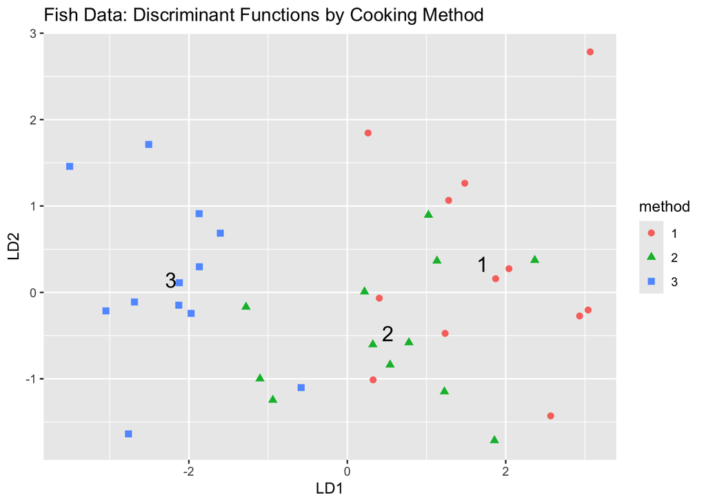

```r
means <- fishLDA |>
  group_by(method) |>
  summarise(meanz1=mean(LD1),
            meanz2=mean(LD2))

ggplot() +
  geom_point(data=fishLDA, mapping=aes(x=LD1, y=LD2, color=method, shape=method), cex=2) +
    geom_point(data=means, mapping=aes(x=meanz1, y=meanz2), cex=5, pch=as.character(means$method)) +
      labs(title="Fish Data: Discriminant Functions by Cooking Method")
```

From this graph, it seems that the first discriminant function is pretty good at separating the third cooking method from the first and second method. This can be seen from the mean vector is as far as possible from the first 2 methods’ mean vectors. However the second discriminant function is not good at separating the first method from the second method as there are overlaps.

# Homework 7: Thursday Exercises

## Question 1

Do a classification analysis on the fish/cooking method data, Table 6.17, the same data you used on Tuesday’s homework.

### (a)

Use both Fisher’s procedure and the quadratic classification procedure to arrive at classification models for the fish data.

Fisher’s Procedure:

```r
fish2LDA <- lda(method ~ ., data = fish)
fish2LDA
```

```
## Call:
## lda(method ~ ., data = fish)
##
## Prior probabilities of groups:
##         1         2         3
## 0.3333333 0.3333333 0.3333333
##
## Group means:
##      aroma   flavor  texture moisture
## 1 5.383333 5.733333 5.441667 5.983333
## 2 5.258333 5.233333 5.308333 5.875000
## 3 4.975000 4.833333 5.908333 6.233333
##
## Coefficients of linear discriminants:
##                 LD1        LD2
## aroma     0.1189475 -1.8229712
## flavor    3.0643528  1.7140180
## texture  -1.9924182  1.3967308
## moisture -0.7759711 -0.1508668
##
## Proportion of trace:
##    LD1    LD2
## 0.9586 0.0414
```

```r
classFish <- predict(fish2LDA)$class
fishFisher <- cbind(fish, classFish)
fishFisher <- fishFisher[, c("method", "classFish", "aroma", "flavor", "texture", "moisture")]
head(fishFisher, n=5)
```

```
##   method classFish aroma flavor texture moisture
## 1      1         1   5.4    6.0     6.3      6.7
## 2      1         1   5.2    6.5     6.0      5.8
## 3      1         2   6.1    5.9     6.0      7.0
## 4      1         2   4.8    5.0     4.9      5.0
## 5      1         1   5.0    5.7     5.0      6.5
```

```r
tail(fishFisher, n=5)
```

```
##    method classFish aroma flavor texture moisture
## 32      3         3   4.8    4.6     5.7      5.7
## 33      3         3   5.3    5.4     6.8      6.6
## 34      3         3   4.6    4.4     5.7      5.6
## 35      3         3   4.5    4.0     5.0      5.9
## 36      3         3   4.4    4.2     5.6      5.5
```

Quadratic Classification Function Procedure:

```r
fishQDA <- qda(method ~ ., data = fish)
fishQDA
```

```
## Call:
## qda(method ~ ., data = fish)
##
## Prior probabilities of groups:
##         1         2         3
## 0.3333333 0.3333333 0.3333333
##
## Group means:
##      aroma   flavor  texture moisture
## 1 5.383333 5.733333 5.441667 5.983333
## 2 5.258333 5.233333 5.308333 5.875000
## 3 4.975000 4.833333 5.908333 6.233333
```

```r
classQuad <- predict(fishQDA)$class
fishQuad <- cbind(fish, classQuad)
fishQuad <- fishQuad[, c("method", "classQuad", "aroma", "flavor", "texture", "moisture")]
head(fishQuad, n=5)
```

```
##   method classQuad aroma flavor texture moisture
## 1      1         1   5.4    6.0     6.3      6.7
## 2      1         1   5.2    6.5     6.0      5.8
## 3      1         1   6.1    5.9     6.0      7.0
## 4      1         2   4.8    5.0     4.9      5.0
## 5      1         1   5.0    5.7     5.0      6.5
```

```r
tail(fishQuad, n=5)
```

```
##    method classQuad aroma flavor texture moisture
## 32      3         3   4.8    4.6     5.7      5.7
## 33      3         3   5.3    5.4     6.8      6.6
## 34      3         3   4.6    4.4     5.7      5.6
## 35      3         3   4.5    4.0     5.0      5.9
## 36      3         3   4.4    4.2     5.6      5.5
```

### (b)

Compare the performance of the two procedures in an honest, less biased way.

```r
confusionMatrix(data = fishFisher$classFish, reference = fishFisher$method)
```

```
## Confusion Matrix and Statistics
##
##           Reference
## Prediction  1  2  3
##          1  9  3  0
##          2  3  7  1
##          3  0  2 11
##
## Overall Statistics
##
##                Accuracy : 0.75
##                  95% CI : (0.578, 0.8788)
##     No Information Rate : 0.3333
##     P-Value [Acc > NIR] : 3.808e-07
##
##                   Kappa : 0.625
##
##  Mcnemar's Test P-Value : NA
##
## Statistics by Class:
##
##                      Class: 1 Class: 2 Class: 3
## Sensitivity            0.7500   0.5833   0.9167
## Specificity            0.8750   0.8333   0.9167
## Pos Pred Value         0.7500   0.6364   0.8462
## Neg Pred Value         0.8750   0.8000   0.9565
## Prevalence             0.3333   0.3333   0.3333
## Detection Rate         0.2500   0.1944   0.3056
## Detection Prevalence   0.3333   0.3056   0.3611
## Balanced Accuracy      0.8125   0.7083   0.9167
```

```r
confusionMatrix(data = fishQuad$classQuad, reference = fishQuad$method)
```

```
## Confusion Matrix and Statistics
##
##           Reference
## Prediction  1  2  3
##          1 10  2  0
##          2  2  8  1
##          3  0  2 11
##
## Overall Statistics
##
##                Accuracy : 0.8056
##                  95% CI : (0.6398, 0.9181)
##     No Information Rate : 0.3333
##     P-Value [Acc > NIR] : 8.036e-09
##
##                   Kappa : 0.7083
##
##  Mcnemar's Test P-Value : NA
##
## Statistics by Class:
##
##                      Class: 1 Class: 2 Class: 3
## Sensitivity            0.8333   0.6667   0.9167
## Specificity            0.9167   0.8750   0.9167
## Pos Pred Value         0.8333   0.7273   0.8462
## Neg Pred Value         0.9167   0.8400   0.9565
## Prevalence             0.3333   0.3333   0.3333
## Detection Rate         0.2778   0.2222   0.3056
## Detection Prevalence   0.3333   0.3056   0.3611
## Balanced Accuracy      0.8750   0.7708   0.9167
```

From this analysis of confusion matrices for the Fisher procedure and quadratic classification function, we used estimates of accuracy/misclassification rates, sensitivity, and specificity to determine the performance of the 2 procedures. Fisher’s procedure resulted in a 75% accuracy or 25% misclassification rate, however the QDA function resulted in a better accuracy of 80.56% which means a 19.4% misclassification rate. This means that the QDA function did a better job at correctly classifying observations than Fisher’s procedure. The sensitivity for Fisher’s was 75%, 58%, and 91.67% respectively for the 3 methods, while for the QDA it was 83%, 66%, and 91.67%. These 2 procedures were more sensitive towards cooking method #3. QDA was more sensitive in classifying methods 1 and 2 as those methods than Fisher’s procedure. The specificity values for Fisher’s procedure are 87.5%, 83%, and 91.67%, while for QDA they were 91.67%, 87.5%, and 91.67%. This means that QDA was much better at classifying records not of a given method that were not classified as that method. Overall, it would seem that QDA did better than Fisher’s procedure.

### (c)

Suppose you were presented with a fish that had the following characteristics, but you didn’t know how it was prepared: Aroma = 4.5, Flavor = 5.2, Texture = 4.8, Moisture = 5.1.

- Predict the preparation method of that dish.

```r
newy <- data.frame(aroma=4.5, flavor=5.2, texture=4.8, moisture=5.1)
newz <- predict(fishQDA, newdata = newy)
newz
```

```
## $class
## [1] 1
## Levels: 1 2 3
##
## $posterior
##           1         2            3
## 1 0.8129999 0.1870001 1.241313e-16
```

The preparation method of that dish with those characteristics is method #1.

- What do you think is the chance you’ve predicted the method correctly?

```r
confusionMatrix(data = fishQuad$classQuad, reference = fishQuad$method)$overall["Accuracy"]
```

```
##  Accuracy
## 0.8055556
```

The chance that I have predicted the method correctly would be the accuracy of the procedure which is 80.56%, which means that across all predictions our model correctly identifies the method 80.56% of the time.

- Suppose this dish was prepared by the method that your classification model predicted. What is the chance that your classification model would predict the correct cooking method?

```r
confusionMatrix(data = fishQuad$classQuad, reference = fishQuad$method)$byClass[1]
```

```
## [1] 0.8333333
```

The chance that my classification model would predict the correct cooking method given that it was prepared by the method that my classification model predicted (method #1) would be the sensitivity of the model towards method #1. That value is 83.33%.